# Homework4

ChenMengJia, BalintParragi

2019 10 25

```r
suppressPackageStartupMessages(library(data.table))
suppressPackageStartupMessages(library(ggplot2))
suppressPackageStartupMessages(library(magrittr))
suppressPackageStartupMessages(library(plotly))
```

#### A spotify 2017-18-as top 100-as listájának adatait elemezzük, mely a rangsorolt dalok számtalan zenei jellemzőjét rögzíti (ezek rövid leírása később). Azt szeretnénk megmagyarázni, hogy van-e összefüggés ezen jellemzők és a toplistán elfoglalt helyezés között. Ezen kívül egy másik alternatív módszerünk, hogy megpróbáljuk leírni, hogy milyen paraméterekkel rendelkező dal kerülhet a toplistára.

```r
top_2017 <- fread("data/top2017.csv", encoding = "UTF-8")
top_2018 <- fread("data/top2018.csv", encoding = "UTF-8")
top_2017[, rank:=1:100]
top_2018[, rank:=1:100]
```

#### Egyes változókat kiszedtünk, mert teljesen irreleváns volt a szerepltetésük (és az értelmük)

```r
top_2017[, c("id", "time_signature", "key", "mode"):=NULL]
top_2018[, c("id", "time_signature", "key", "mode"):=NULL]
#danceability: tempo, rhythm, stability, beat strength
#energy: intensity & activity & loudness
#loudness: deciBels
#spechiness: 0.33 és 0.66 között zene és szöveg <-> instrumentalness
#valence: 0-szomorú 1-happy
#tempo: BPM
#duration_ms: milliseconds
```

```r
top100_music <- merge(top_2017, top_2018, all = TRUE)
```

#### adattisztítás: néhány dal mindkét év toplistáján szerepelt, ezektől megtisztítottuk az adatokat

```r
top100_unique <- unique(top100_music, by = "name")
```

#### Néhány kezdeti ábra

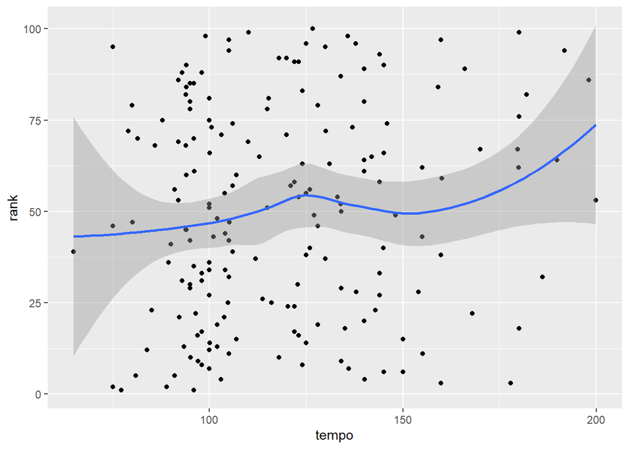

```r
ggplot(top100_unique, aes(tempo, rank))+ geom_point()+geom_smooth()
```

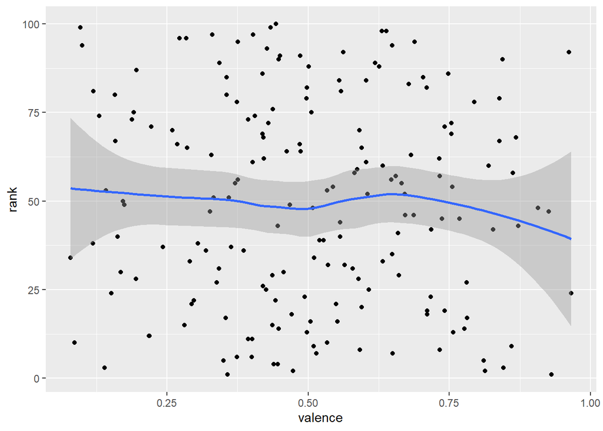

```r
ggplot(top100_unique, aes(valence, rank))+ geom_point()+geom_smooth()
```

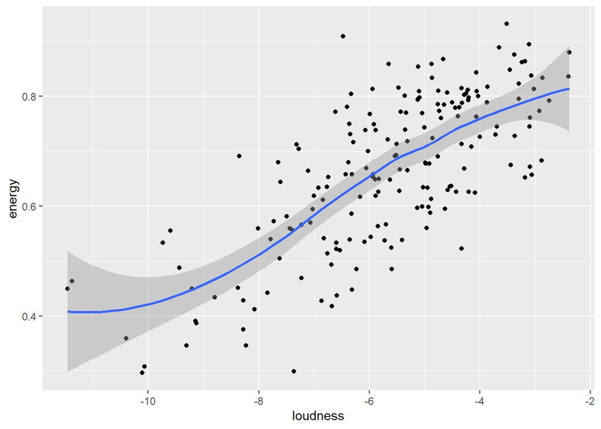

```r
ggplot(top100_unique, aes(loudness, energy))+ geom_point()+geom_smooth()
```

```r
cor(top100_unique[, c("artists", "name"):=NULL])
```

```
##                  danceability      energy    loudness  speechiness
## danceability       1.00000000 -0.08978699  0.03840868  0.169645201
## energy            -0.08978699  1.00000000  0.72982904 -0.157737490
## loudness           0.03840868  0.72982904  1.00000000 -0.347069426
## speechiness        0.16964520 -0.15773749 -0.34706943  1.000000000
## acousticness      -0.06934594 -0.33542133 -0.22521751 -0.075448551
## instrumentalness  -0.01843730  0.06286060 -0.04459569 -0.065177686
## liveness          -0.03591626  0.07673146  0.02126248 -0.062606072
## valence            0.38521962  0.35213092  0.41645777 -0.101929477
## tempo             -0.25639698  0.02895418 -0.09724673  0.151116853
## duration_ms       -0.03282462  0.02207676  0.08082185 -0.008140845
## rank              -0.06672465 -0.03685378 -0.07656211  0.051216342
##                  acousticness instrumentalness    liveness     valence
## danceability      -0.06934594    -0.0184373004 -0.03591626  0.38521962
## energy            -0.33542133     0.0628606034  0.07673146  0.35213092
## loudness          -0.22521751    -0.0445956862  0.02126248  0.41645777
## speechiness       -0.07544855    -0.0651776864 -0.06260607 -0.10192948
## acousticness       1.00000000    -0.0558327867 -0.14718059  0.01602253
## instrumentalness  -0.05583279     1.0000000000 -0.03268502 -0.03846770
## liveness          -0.14718059    -0.0326850179  1.00000000 -0.03513121
## valence            0.01602253    -0.0384676975 -0.03513121  1.00000000
## tempo             -0.15860938     0.1114286460 -0.04118117 -0.19643160
## duration_ms       -0.05142158     0.0003075136 -0.05035565 -0.11442735
## rank               0.02997533    -0.0659478954 -0.10603040 -0.04983333
##                         tempo   duration_ms        rank
## danceability     -0.256396981 -0.0328246151 -0.06672465
## energy            0.028954178  0.0220767644 -0.03685378
## loudness         -0.097246732  0.0808218476 -0.07656211
## speechiness       0.151116853 -0.0081408447  0.05121634
## acousticness     -0.158609376 -0.0514215781  0.02997533
## instrumentalness  0.111428646  0.0003075136 -0.06594790
## liveness         -0.041181174 -0.0503556508 -0.10603040
## valence          -0.196431599 -0.1144273475 -0.04983333
## tempo             1.000000000  0.0092492512  0.12309734
## duration_ms       0.009249251  1.0000000000 -0.08179763
## rank              0.123097337 -0.0817976345  1.00000000
```

#### Mint látható a korrelációs mátrixból és az ábrákból, a rank igazán semmivel sem korrelál, egyes más változók egymással viszont elég erősen.Ennek ellenére érdemesnek tartjuk továbbvinni ezt az elméletet és regressziót futtatni.

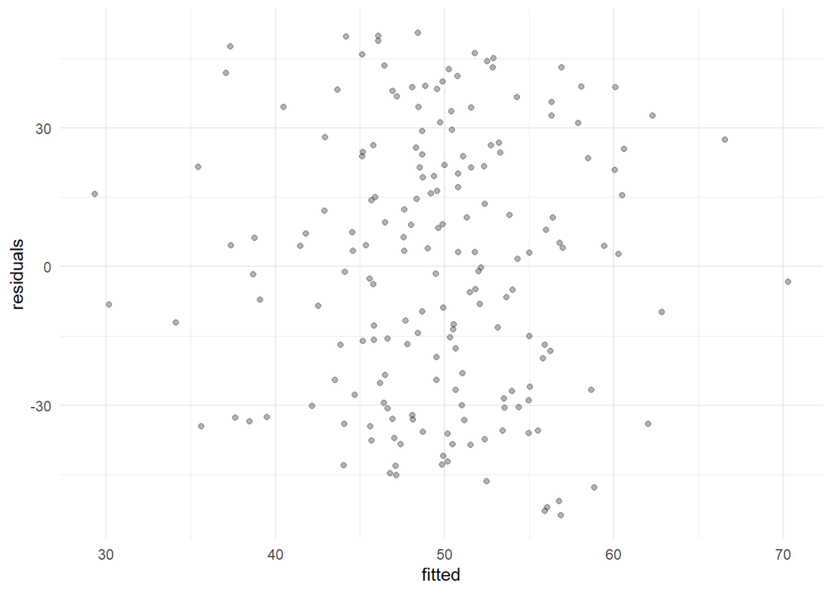

```r
lm1 <- lm(rank ~ ., data = top100_unique)
residuals <- data.table(residuals = lm1$residuals, fitted = lm1$fitted.values)
ggplot(residuals, aes(fitted, residuals)) +
    geom_point(alpha = .3) +
    theme_minimal()
```

#### A maradéktagokat mutató ábra alapján az elmondható, hogy azok randomok, így nem maradt ki szisztematikus hatás.

```r
summary(lm1)
```

```
##
## Call:
## lm(formula = rank ~ ., data = top100_unique)
##
## Residuals:
##     Min      1Q  Median      3Q     Max
## -53.864 -26.510   2.859  23.877  50.579
##
## Coefficients:
##                    Estimate Std. Error t value Pr(>|t|)
## (Intercept)       4.876e+01  3.648e+01   1.337    0.183
## danceability     -8.111e+00  2.060e+01  -0.394    0.694
## energy            8.159e+00  2.471e+01   0.330    0.742
## loudness         -1.233e+00  1.976e+00  -0.624    0.533
## speechiness       1.960e+00  2.410e+01   0.081    0.935
## acousticness      2.483e+00  1.245e+01   0.199    0.842
## instrumentalness -1.322e+02  1.145e+02  -1.154    0.250
## liveness         -3.181e+01  2.209e+01  -1.440    0.152
## valence          -1.803e+00  1.289e+01  -0.140    0.889
## tempo             1.137e-01  8.248e-02   1.378    0.170
## duration_ms      -6.485e-05  5.769e-05  -1.124    0.263
##
## Residual standard error: 29.15 on 175 degrees of freedom
## Multiple R-squared:  0.0461, Adjusted R-squared:  -0.00841
## F-statistic: 0.8457 on 10 and 175 DF,  p-value: 0.5853
```

#### Ellenben a p (és t) értékekből látszik, hogy a modellünk egyik magyarázó változója sem szignifikáns (ami a korrelációs mátrixból sejthető volt)

```r
lm2 <- lm(rank ~ tempo + liveness, data = top100_unique)
summary(lm2)
```

```
##
## Call:
## lm(formula = rank ~ tempo + liveness, data = top100_unique)
##
## Residuals:
##     Min      1Q  Median      3Q     Max
## -55.116 -26.253   2.446  24.236  50.523
##
## Coefficients:
##              Estimate Std. Error t value Pr(>|t|)
## (Intercept)  39.68436    9.88838   4.013 8.72e-05 ***
## tempo         0.12226    0.07508   1.628    0.105
## liveness    -29.55424   21.34484  -1.385    0.168
## ---
## Signif. codes:  0 '***' 0.001 '**' 0.01 '*' 0.05 '.' 0.1 ' ' 1
##
## Residual standard error: 28.81 on 183 degrees of freedom
## Multiple R-squared:  0.02536,    Adjusted R-squared:  0.01471
## F-statistic: 2.381 on 2 and 183 DF,  p-value: 0.0953
```

#### Az új lineáris regresszióban benne hagytuk a teljes modellből (lm1) a két legkisebb p-értékű tagot, azonban ezek p-értéke és így szignifikanciája nem változott. A rank ezzel a két változóval korrelált leginkább kezdetben.

#### Interakció hozzáadásának nem láttuk értelmét (nincs értelme ezen változók kombinálásának), viszont az egyértelmű, hogy a modellnek nincs magyarázóereje. Ezt a további feladatok során kétféle módon próbáljuk orvosolni. Az egyik, hogy nem a rank lesz a függő változó (és más modellt építünK), a másik pedig (mely inkább értelmes feladat), hogy leírni és jellemezni próbáljuk ezeket a zeneszámokat, hogy mégis miért kerülhettek be a top100-ba. Továbbá természetesen előfordulhat, hogy meglévő változókon kívül igazából teljesen más tényezők magyarázzák a toplistás helyezést (ízlés, előadó hírneve, divat, előadóval kapcsolatos hírek és történések stb.).

#### További ötletünk, hogy a test és train adatokat a külön évek adataiból hozzuk létre, azaz az egyik év adatain traineljük a modellt (pl. 2017) és a másikon (pl. 2018) teszteljük azt.